## Installed libraries and Download Data

```r
library(caret)
```

```r
library(AppliedPredictiveModeling)
library(ggplot2)
library(corrplot)
traindata = read.csv("~/Coursera R courses/pml-training.csv")
testdata = read.csv("~/Coursera R courses/pml-testing.csv")
```

Next look at the structure of the training data.

```r
str(traindata)
```

```
## 'data.frame':    19622 obs. of  160 variables:
##  $ X                       : int  1 2 3 4 5 6 7 8 9 10 ...
##  $ user_name               : chr  "carlitos" "carlitos" "carlitos" "carlitos" ...
##  $ raw_timestamp_part_1    : int  1323084231 1323084231 1323084231 1323084232 1323084232 1323084232 1323084232 1323084232 1323084232 1323084232 ...
##  $ raw_timestamp_part_2    : int  788290 808298 820366 120339 196328 304277 368296 440390 484323 484434 ...
##  $ cvtd_timestamp          : chr  "05/12/2011 11:23" "05/12/2011 11:23" "05/12/2011 11:23" "05/12/2011 11:23" ...
##  $ new_window              : chr  "no" "no" "no" "no" ...
##  $ num_window              : int  11 11 11 12 12 12 12 12 12 12 ...
##  $ roll_belt               : num  1.41 1.41 1.42 1.48 1.48 1.45 1.42 1.42 1.43 1.45 ...
##  $ pitch_belt              : num  8.07 8.07 8.07 8.05 8.07 8.06 8.09 8.13 8.16 8.17 ...
##  $ yaw_belt                : num  -94.4 -94.4 -94.4 -94.4 -94.4 -94.4 -94.4 -94.4 -94.4 -94.4 ...
##  $ total_accel_belt        : int  3 3 3 3 3 3 3 3 3 3 ...
##  $ kurtosis_roll_belt      : chr  "" "" "" "" ...
##  $ kurtosis_picth_belt     : chr  "" "" "" "" ...
##  $ kurtosis_yaw_belt       : chr  "" "" "" "" ...
```

[output cut: 86 more lines]

A number of columns have no information, so those columns are removed as well as the first 7 columns which are not about any movement or exercise.

```r
colname <-colnames(traindata)[!colSums(is.na(traindata))>0]
colname <- colname[8:93]
cleantrain <-traindata[colname]
```

Finally we remove the variables which are character class.

```r
numeric <- cleantrain[sapply(cleantrain,is.numeric)]
data <- cbind(numeric,classe=traindata$classe)
```

Now we set testdata with same variables:

```r
colname <-colnames(data)
validdata <-testdata[colname[-53]]
```

Next we set the seed equal to 5270 and pull our train and test samples.

```r
set.seed(5270)
inTrain = createDataPartition(data$classe, p = 0.7)[[1]]
training = data[ inTrain,]
testing = data[-inTrain,]
```

Make sure classe is a factor in the testing group so crossvalidation can occur.

```r
testing$classe <- as.factor(testing$classe)
```

## Look for correlated predictors

```r
cormatrix <- cor(training[,-53])
M<-abs(cormatrix)
diag(M)<-0
which(M>0.8,arr.ind=T)
```

```
##                  row col
## yaw_belt           3   1
## total_accel_belt   4   1
## accel_belt_y       9   1
## accel_belt_z      10   1
## accel_belt_x       8   2
## magnet_belt_x     11   2
## roll_belt          1   3
## roll_belt          1   4
## accel_belt_y       9   4
## accel_belt_z      10   4
## pitch_belt         2   8
## magnet_belt_x     11   8
## roll_belt          1   9
## total_accel_belt   4   9
## accel_belt_z      10   9
## roll_belt          1  10
## total_accel_belt   4  10
## accel_belt_y       9  10
## pitch_belt         2  11
## accel_belt_x       8  11
## magnet_belt_z     13  12
## magnet_belt_y     12  13
## gyros_arm_y       19  18
## gyros_arm_x       18  19
## magnet_arm_x      24  21
## accel_arm_x       21  24
## magnet_arm_z      26  25
## magnet_arm_y      25  26
## accel_dumbbell_x  34  28
## accel_dumbbell_z  36  29
## pitch_dumbbell    28  34
## yaw_dumbbell      29  36
```

This suggests the highly correlated variables are: gyros_arm_x and gyros_arm_y; accel_arm_x and magnet_arm_x; magnet_arm_y and magnet_arm_z; accel_dumbbell_x and pitch_dumbbell; accel_dumbbell_z and yaw_dumbbell.

Here is a plot of the correlations:

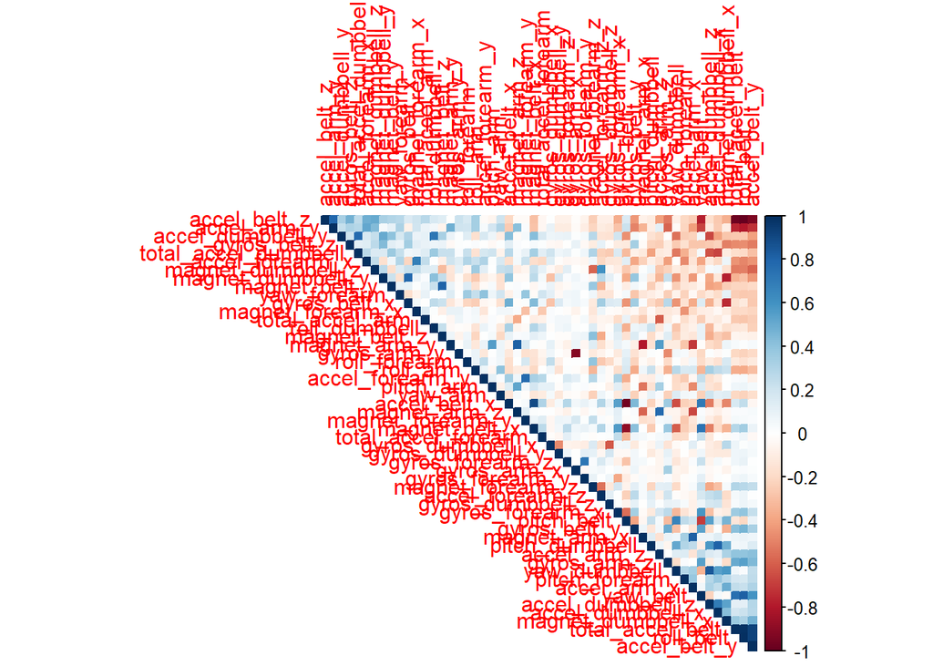

## Fit models

The models we will fit are rf, gbm, and lda.

### Random Forest model

```r
controlRF <-trainControl(method="cv",number=3)
modFit1 <- train(classe~.,data=training,method="rf",trControl=controlRF)
modFit1$finalModel
```

```
##
## Call:
##  randomForest(x = x, y = y, mtry = param$mtry)
##                Type of random forest: classification
##                      Number of trees: 500
## No. of variables tried at each split: 27
##
##         OOB estimate of  error rate: 0.69%
## Confusion matrix:
##      A    B    C    D    E class.error
## A 3899    5    2    0    0 0.001792115
## B   19 2629    9    0    1 0.010910459
## C    0   10 2379    7    0 0.007095159
## D    0    1   25 2224    2 0.012433393
## E    0    3    4    7 2511 0.005544554
```

```r
predRF <- predict(modFit1,newdata=testing)
cmRF <- confusionMatrix(testing$classe,predRF)
cmRF
```

```
## Confusion Matrix and Statistics
##
##           Reference
## Prediction    A    B    C    D    E
##          A 1673    0    0    0    1
##          B   15 1123    1    0    0
##          C    0    1 1023    2    0
##          D    0    0   10  954    0
##          E    0    0    0    5 1077
##
## Overall Statistics
##
##                Accuracy : 0.9941
##                  95% CI : (0.9917, 0.9959)
##     No Information Rate : 0.2868
##     P-Value [Acc > NIR] : < 2.2e-16
##
##                   Kappa : 0.9925
##
##  Mcnemar's Test P-Value : NA
##
## Statistics by Class:
##
##                      Class: A Class: B Class: C Class: D Class: E
## Sensitivity            0.9911   0.9991   0.9894   0.9927   0.9991
## Specificity            0.9998   0.9966   0.9994   0.9980   0.9990
## Pos Pred Value         0.9994   0.9860   0.9971   0.9896   0.9954
## Neg Pred Value         0.9964   0.9998   0.9977   0.9986   0.9998
## Prevalence             0.2868   0.1910   0.1757   0.1633   0.1832
## Detection Rate         0.2843   0.1908   0.1738   0.1621   0.1830
## Detection Prevalence   0.2845   0.1935   0.1743   0.1638   0.1839
## Balanced Accuracy      0.9954   0.9979   0.9944   0.9953   0.9990
```

### Gradient Boosted Model

```r
controlgbm <- trainControl(method="cv",number=3)
modFit2 <- train(classe ~., method="gbm", data=training,trControl=controlgbm,verbose=FALSE)
modFit2$finalModel
```

```
## A gradient boosted model with multinomial loss function.
## 150 iterations were performed.
## There were 52 predictors of which 52 had non-zero influence.
```

```r
predgbm <- predict(modFit2,newdata=testing)
confusionMatrix(testing$classe,predgbm)
```

```
## Confusion Matrix and Statistics
##
##           Reference
## Prediction    A    B    C    D    E
##          A 1640   22    8    2    2
##          B   46 1065   24    4    0
##          C    0   30  980   12    4
##          D    0    2   38  919    5
##          E    0   14    5   19 1044
##
## Overall Statistics
##
##                Accuracy : 0.9597
##                  95% CI : (0.9544, 0.9646)
##     No Information Rate : 0.2865
##     P-Value [Acc > NIR] : < 2.2e-16
##
##                   Kappa : 0.9491
##
##  Mcnemar's Test P-Value : 1.027e-08
##
## Statistics by Class:
##
##                      Class: A Class: B Class: C Class: D Class: E
## Sensitivity            0.9727   0.9400   0.9289   0.9613   0.9896
## Specificity            0.9919   0.9844   0.9905   0.9909   0.9921
## Pos Pred Value         0.9797   0.9350   0.9552   0.9533   0.9649
## Neg Pred Value         0.9891   0.9857   0.9846   0.9925   0.9977
## Prevalence             0.2865   0.1925   0.1793   0.1624   0.1793
## Detection Rate         0.2787   0.1810   0.1665   0.1562   0.1774
## Detection Prevalence   0.2845   0.1935   0.1743   0.1638   0.1839
## Balanced Accuracy      0.9823   0.9622   0.9597   0.9761   0.9909
```

### Linear Discriminant Analysis

```r
controllda <-trainControl(method="cv",number=3)
modFit3 <- train(classe ~., method="lda", data=training,trControl=controllda,verbose=FALSE)
predlda <- predict(modFit3,newdata=testing)
confusionMatrix(testing$classe,predlda)
```

```
## Confusion Matrix and Statistics
##
##           Reference
## Prediction    A    B    C    D    E
##          A 1396   36  112  124    6
##          B  188  728  127   40   56
##          C  120   79  681  117   29
##          D   53   40  128  708   35
##          E   46  181   97  117  641
##
## Overall Statistics
##
##                Accuracy : 0.7059
##                  95% CI : (0.694, 0.7175)
##     No Information Rate : 0.3064
##     P-Value [Acc > NIR] : < 2.2e-16
##
##                   Kappa : 0.6273
##
##  Mcnemar's Test P-Value : < 2.2e-16
##
## Statistics by Class:
##
##                      Class: A Class: B Class: C Class: D Class: E
## Sensitivity            0.7743   0.6842   0.5948   0.6401   0.8357
## Specificity            0.9319   0.9147   0.9272   0.9464   0.9138
## Pos Pred Value         0.8339   0.6392   0.6637   0.7344   0.5924
## Neg Pred Value         0.9033   0.9292   0.9045   0.9191   0.9738
## Prevalence             0.3064   0.1808   0.1946   0.1879   0.1303
## Detection Rate         0.2372   0.1237   0.1157   0.1203   0.1089
## Detection Prevalence   0.2845   0.1935   0.1743   0.1638   0.1839
## Balanced Accuracy      0.8531   0.7995   0.7610   0.7933   0.8748
```

## Conclusion

Based upon this output, the random forest provides the best model for predicting classe. See the plot below with predicted versus actual

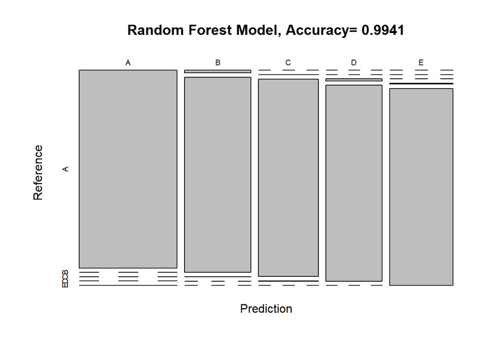

## Predicted values

Now we will find the predicted values for the testing data.

```r
predict(modFit1,newdata=validdata)
```

```
##  [1] B A B A A E D B A A B C B A E E A B B B
## Levels: A B C D E
```